# Mummichog Report: data_pos_group2_before_blank_subtraction

mummichog version: 2.2.0-20200207, using metabolic model MFN_1.10.4.

## User input data

User supplied 7673 features as reference list.We are using 1483 features (p < 0.050000) as significant list. The feature level data are shown in the Manhattan plots below.

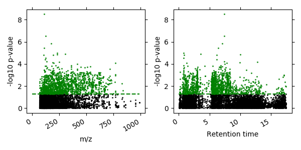

## Top pathways

| Pathways | overlap_size | pathway_size | p-value | overlap_EmpiricalCompounds |
| --- | --- | --- | --- | --- |
| Aspartate and asparagine metabolism | 40 | 103 | 0.00429 | E143,E401,E855,E246,E368,E1316,E1413,E1431,E237,E360,E742,E1015,E900,E423,E356,E821,E487,E557,E254,E1310,E1491,E1386,E1293,E1155,E5,E1374,E172,E1250,E2,E1292,E1178,E88,E14,E228,E889,E426,E870,E1427,E6… |
| Glutathione Metabolism | 12 | 24 | 0.00941 | E237,E401,E88,E855,E810,E426,E1178,E126,E5,E1374,E577,E515 |
| Drug metabolism - cytochrome P450 | 7 | 12 | 0.01462 | E1001,E904,E1336,E781,E188,E819,E1479 |
| Glutamate metabolism | 12 | 28 | 0.03395 | E19,E88,E855,E515,E810,E1178,E441,E126,E5,E1431,E80,E780 |
| Androgen and estrogen biosynthesis and metabolism | 7 | 15 | 0.05546 | E947,E88,E855,E907,E1348,E511,E1178 |

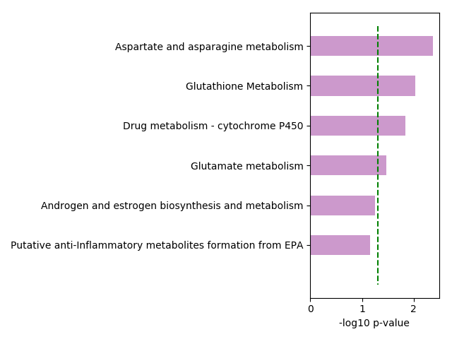

## Top modules

module_1, p=0.00131, 14 metabolites

L-Adrenaline; (R)-(-)-Adrenaline; (R)-(-)-Epinephrine; (R)-(-)-Epirenamine; (R)-(-)-Adnephrine; 4-[(1R)-1-Hydroxy-2-(methylamino)ethyl]-1,2-benzenediol, L-Normetanephrine, 3-Methylimidazoleacetic acid, Indole-3-acetaldehyde, Histamine, Serotonin, N-Methylhistamine, 3,4-Dihydroxyphenylacetaldehyde; Protocatechuatealdehyde, Phenethylamine, 3-Methylimidazole acetaldehyde, 3-Methoxytyramine, Citalopram, Phenylacetaldehyde; alpha-Tolualdehyde, N4-Acetylaminobutanal

module_2, p=0.01445, 99 metabolites

L-Glutamate, L-Proline, Phenethylamine, 3-Methyl-2-oxobutanoate, Adenine, L-Adrenaline; (R)-(-)-Adrenaline; (R)-(-)-Epinephrine; (R)-(-)-Epirenamine; (R)-(-)-Adnephrine; 4-[(1R)-1-Hydroxy-2-(methylamino)ethyl]-1,2-benzenediol, N,N-Dimethylglycine; Dimethylglycine, N-Carbamoyl-L-aspartate, Purine, Urocanate, 2-keto-4-methylthiobutyrate, 3-Methylimidazoleacetic acid, Nicotinamide, L-Asparagine, 3-Methylimidazole acetaldehyde, Histamine, 5,6-dihydrouracil, Guanosine, Cytosine, L-3-Amino-isobutanoate, N-acetyl-L-alanine, 5-Oxo-L-proline, dUMP, 1-Pyrroline-5-carboxylate, Beta cyanoalanine, 3-Aminoisobutyric acid; 3-Aminoisobutanoate; 3-Amino-2-methylpropanoate, 5-L-Glutamyl-L-alanine, beta-Alanine, Itaconate; Itaconic acid; Methylenesuccinic acid, Spermidine, D-Proline, L-Carnitine, 2-Aminomuconate, L-Cysteine, Glycine betaine, L-Methionine, 2'-Deoxyinosine 5'-phosphate; dIMP, dATP, D-Serine, Urea, (S)-2-Aminobutanoate; (S)-2-Aminobutanoic acid; (S)-2-Aminobutyric acid, trans-4-Hydroxy-L-proline, L-Isoleucine, L-4-Hydroxyglutamate semialdehyde, N-Methylhistamine, N4-Acetylaminobutanal, Uracil, Citalopram, L-Arginine, L-Serine, DL-Glutamate; DL-Glutaminic acid; 2-Aminoglutaric acid; Glutamate, Anthranilate, 5'-Deoxy-5-fluorocytidine, Benzo[a]pyrene-4,5-oxide; Benzo[a]pyrene-4,5-epoxide, 5,6-Dihydrothymine, 1-Pyrroline-2-carboxylate; 1-Pyrroline-2-carboxylic acid; delta1-Pyrroline 2-carboxylate, beta-Alanyl-N(pi)-methyl-L-histidine; Anserine, 5-Oxoproline, Inosine, Thioguanine, Uridine, Indole-3-acetaldehyde, Hypoxanthine, L-Threonine, acetamidopropanal, N2-Succinyl-L-ornithine; (2S)-5-Amino-2-(3-carboxypropanoylamino)pentanoic acid, L-Valine, D-Ribose, L-Leucine, 2-Oxoadipate, dopamine o-quinone, L-Citrulline; 2-Amino-5-ureidovaleric acid; Citrulline, L-Glutamate 5-semialdehyde; L-Glutamate gamma-semialdehyde, L-Normetanephrine, 2-Aminoacrylate; Dehydroalanine, 3-Methoxytyramine, Lipoate; Lipoic acid; alpha-Lipoic acid; Thioctic acid, Reduced glutathione, Phenylacetaldehyde; alpha-Tolualdehyde, N-Acetylmethionine, Sarcosine; N-Methylglycine, D-3-Amino-isobutanoate, 1-pyrroline, L-Histidine, D-Alanine, 4-Aminobutanoate, dehydrospermidine, Imidazole-4-acetaldehyde; Imidazole acetaldehyde, N6-Acetyl-L-lysine, Serotonin, L-1-Pyrroline-3-hydroxy-5-carboxylate, Deoxyuridine, 3,4-Dihydroxyphenylacetaldehyde; Protocatechuatealdehyde, N6-(L-1,3-Dicarboxypropyl)-L-lysine; Saccharopine; L-Saccharopine; N-[(S)-5-Amino-5-carboxypentyl]-L-glutamic acid, Succinate, L-Alanine, L-Lysine, L-Aspartate, N-Carbamoyl-beta-alanine

## EmpiricalCompounds favored by above analyses

An EmpiricalCompound is a computational unit for a tentative metabolite. It can group multiple ions, and be any of the isobaric/isomeric species. This table contains EmpiricalCompounds prioritized by pathway/module analysis.

| EmpiricalCompound | Input m/z | Retention time | ion | mz_diff | Statistic | Significant |
| --- | --- | --- | --- | --- | --- | --- |
| E677 | Best guess: C03415, N2-Succinyl-L-ornithine |  | C03415 |  |  |  |
|  | 255.09552887 | 2.95324333333 | M+Na[1+] | 0.0004 | -3.75 | yes |
| E1392 | Best guess: C00449, N6-(L-1,3-Dicarboxypropyl)-L-lysine |  | C00449 |  |  |  |
|  | 276.134664875 | 6.97385208333 | M[1+] | 0.0026 | -2.96 | yes |
|  | 299.122747412 | 7.17307291667 | M+Na[1+] | 0.0014 | -2.56 | yes |
| E377 | Best guess: C00388, Histamine |  | C00388 |  |  |  |
|  | 112.087527312 | 1.68165757576 | M+H[1+] | 0.0007 | -0.94 | no |
|  | 112.087559669 | 1.36779318182 | M+H[1+] | 0.0007 | -3.49 | yes |
|  | 112.087570486 | 1.44141212121 | M+H[1+] | 0.0007 | -2.44 | yes |
| E1015 | Best guess: C00437, N2-Acetyl-L-ornithine |  | C00437 |  |  |  |
|  | 175.107840883 | 2.045425 | M+H[1+] | 0.0002 | -2.59 | yes |
| E1095 | Best guess: C00294, Inosine |  | C00294 |  |  |  |
|  | 269.087895169 | 5.44527307692 | M+H[1+] | -0.0002 | -2.21 | yes |
| E821 | Best guess: C00152, L-Asparagine |  | C02642, C00152 |  |  |  |
|  | 133.061140427 | 2.18105 | M+H[1+] | 0.0004 | -2.75 | yes |
| E487 | Best guess: C03196, (S)-2-Hydroxyglutarate |  | C02266, C01087, C02630, C03196 |  |  |  |
|  | 171.02676573 | 1.61818529412 | M+Na[1+] | 0.0003 | -4.03 | yes |
| E855 | Best guess: C00051, Reduced glutathione |  | C00051 |  |  |  |
|  | 308.090851129 | 2.15131666667 | M+H[1+] | -0.0002 | -1.59 | no |
|  | 308.090902282 | 2.017065625 | M+H[1+] | -0.0002 | -2.17 | yes |
| E466 | Best guess: C00262, Hypoxanthine |  | C00262 |  |  |  |
|  | 159.028074169 | 3.08797878788 | M+Na[1+] | 0.0003 | -1.85 | no |
|  | 136.038992109 | 2.98618560606 | M[1+] | 0.0005 | -4.09 | yes |
| E744 | Best guess: C02218, 2-Aminoacrylate |  | C02218 |  |  |  |
|  | 156.026691026 | 1.31592666667 | M+HCOONa[1+] | 0.0 | -2.34 | yes |
|  | 88.0400252592 | 1.04491060606 | M+H[1+] | 0.0007 | -1.8 | no |
|  | 88.0400026556 | 0.784945454545 | M+H[1+] | 0.0007 | -3.97 | yes |
| E356 | Best guess: C03415, N2-Succinyl-L-ornithine |  | C03415 |  |  |  |
|  | 233.113543715 | 1.43099122807 | M+H[1+] | 0.0004 | -2.1 | no |
|  | 233.11359531 | 1.76603947368 | M+H[1+] | 0.0004 | -1.58 | no |

[output cut: 482 more lines]

## More data

Full data tables from pathway analysis, module analysis and activity network are stored in the 'tables/' directory. The tsv files can be imported into a spreadsheet program, e.g. MS Excel. Under the 'figures/network_modules/' directory are files intended for Cytoscape (cytoscape.org) visualization. Please refer to Cytoscape's guides for details. Details of this run are recorded in file mummichog.log.txt.